# Method seminar: Improving the credibility of future research

Author: Lars Schilling

Date: 2025-02-09

# Settings

```r
#global output setting
knitr::opts_chunk$set(echo = TRUE)

#information about R-Studio version
```

```r
# set eval = TRUE to run the installations (recommended to install packages separately from the script)
install.packages("rnaturalearth") #for geographical data
install.packages("dplyr") #for basic tidy functions
install.packages("stringr") #for sanity checks
install.packages("ggplot2") #for basic plotting
install.packages("kntir") #for adjusting the html-output tables
install.packages("kableExtra") #for adjusting the html-output tables
```

```r
library(rnaturalearth)
library(dplyr)
library(stringr)
library(ggplot2)
library(knitr)
library(kableExtra)
```

# Data wrangling

## Loading of the geographical data

```r
countries <- rnaturalearth::ne_countries(continent = "europe", returnclass = "sf") #loading data of European countries and their borders from the package "rnaturalearth"

#print out (for selected columns to not display to much unnecessary information)
kable(countries[, c("name", "iso_a3_eh", "geometry")], format = "html") |>
  scroll_box(width = "100%", height = "400px")
```

|  | name | iso_a3_eh | geometry |
| --- | --- | --- | --- |
| 19 | Russia | RUS | MULTIPOLYGON (((178.7253 71… |
| 22 | Norway | NOR | MULTIPOLYGON (((15.14282 79… |
| 44 | France | FRA | MULTIPOLYGON (((-51.6578 4…. |
| 111 | Sweden | SWE | MULTIPOLYGON (((11.02737 58… |
| 112 | Belarus | BLR | MULTIPOLYGON (((28.17671 56… |
| 113 | Ukraine | UKR | MULTIPOLYGON (((31.78599 52… |
| 114 | Poland | POL | MULTIPOLYGON (((23.48413 53… |
| 115 | Austria | AUT | MULTIPOLYGON (((16.97967 48… |
| 116 | Hungary | HUN | MULTIPOLYGON (((22.08561 48… |
| 117 | Moldova | MDA | MULTIPOLYGON (((26.61934 48… |
| 118 | Romania | ROU | MULTIPOLYGON (((28.23355 45… |
| 119 | Lithuania | LTU | MULTIPOLYGON (((26.49433 55… |
| 120 | Latvia | LVA | MULTIPOLYGON (((27.28818 57… |
| 121 | Estonia | EST | MULTIPOLYGON (((27.98113 59… |
| 122 | Germany | DEU | MULTIPOLYGON (((14.11969 53… |
| 123 | Bulgaria | BGR | MULTIPOLYGON (((22.65715 44… |
| 124 | Greece | GRC | MULTIPOLYGON (((26.29 35.29… |
| 126 | Albania | ALB | MULTIPOLYGON (((21.02004 40… |
| 127 | Croatia | HRV | MULTIPOLYGON (((16.56481 46… |
| 128 | Switzerland | CHE | MULTIPOLYGON (((9.594226 47… |
| 129 | Luxembourg | LUX | MULTIPOLYGON (((6.043073 50… |
| 130 | Belgium | BEL | MULTIPOLYGON (((6.156658 50… |
| 131 | Netherlands | NLD | MULTIPOLYGON (((6.90514 53…. |
| 132 | Portugal | PRT | MULTIPOLYGON (((-9.034818 4… |
| 133 | Spain | ESP | MULTIPOLYGON (((-7.453726 3… |
| 134 | Ireland | IRL | MULTIPOLYGON (((-6.197885 5… |
| 142 | Italy | ITA | MULTIPOLYGON (((10.4427 46…. |
| 143 | Denmark | DNK | MULTIPOLYGON (((9.921906 54… |
| 144 | United Kingdom | GBR | MULTIPOLYGON (((-6.197885 5… |
| 145 | Iceland | ISL | MULTIPOLYGON (((-14.5087 66… |
| 151 | Slovenia | SVN | MULTIPOLYGON (((13.80648 46… |
| 152 | Finland | FIN | MULTIPOLYGON (((28.59193 69… |
| 153 | Slovakia | SVK | MULTIPOLYGON (((22.55814 49… |
| 154 | Czechia | CZE | MULTIPOLYGON (((15.017 51.1… |
| 171 | Bosnia and Herz. | BIH | MULTIPOLYGON (((18.56 42.65… |
| 172 | North Macedonia | MKD | MULTIPOLYGON (((22.38053 42… |
| 173 | Serbia | SRB | MULTIPOLYGON (((18.82982 45… |
| 174 | Montenegro | MNE | MULTIPOLYGON (((20.0707 42…. |
| 175 | Kosovo | -99 | MULTIPOLYGON (((20.59025 41… |

## Tidying the geographical data

```r
countries_tidied <- countries |> #select and rename relevant columns
  select(name = name, country_code = iso_a3_eh, borders = geometry)

#print out
kable(countries_tidied, format = "html") |>
  scroll_box(width = "100%", height = "400px")
```

|  | name | country_code | borders |
| --- | --- | --- | --- |
| 19 | Russia | RUS | MULTIPOLYGON (((178.7253 71… |
| 22 | Norway | NOR | MULTIPOLYGON (((15.14282 79… |
| 44 | France | FRA | MULTIPOLYGON (((-51.6578 4…. |
| 111 | Sweden | SWE | MULTIPOLYGON (((11.02737 58… |
| 112 | Belarus | BLR | MULTIPOLYGON (((28.17671 56… |
| 113 | Ukraine | UKR | MULTIPOLYGON (((31.78599 52… |
| 114 | Poland | POL | MULTIPOLYGON (((23.48413 53… |
| 115 | Austria | AUT | MULTIPOLYGON (((16.97967 48… |
| 116 | Hungary | HUN | MULTIPOLYGON (((22.08561 48… |
| 117 | Moldova | MDA | MULTIPOLYGON (((26.61934 48… |
| 118 | Romania | ROU | MULTIPOLYGON (((28.23355 45… |
| 119 | Lithuania | LTU | MULTIPOLYGON (((26.49433 55… |
| 120 | Latvia | LVA | MULTIPOLYGON (((27.28818 57… |
| 121 | Estonia | EST | MULTIPOLYGON (((27.98113 59… |
| 122 | Germany | DEU | MULTIPOLYGON (((14.11969 53… |
| 123 | Bulgaria | BGR | MULTIPOLYGON (((22.65715 44… |
| 124 | Greece | GRC | MULTIPOLYGON (((26.29 35.29… |
| 126 | Albania | ALB | MULTIPOLYGON (((21.02004 40… |
| 127 | Croatia | HRV | MULTIPOLYGON (((16.56481 46… |
| 128 | Switzerland | CHE | MULTIPOLYGON (((9.594226 47… |
| 129 | Luxembourg | LUX | MULTIPOLYGON (((6.043073 50… |
| 130 | Belgium | BEL | MULTIPOLYGON (((6.156658 50… |
| 131 | Netherlands | NLD | MULTIPOLYGON (((6.90514 53…. |
| 132 | Portugal | PRT | MULTIPOLYGON (((-9.034818 4… |
| 133 | Spain | ESP | MULTIPOLYGON (((-7.453726 3… |
| 134 | Ireland | IRL | MULTIPOLYGON (((-6.197885 5… |
| 142 | Italy | ITA | MULTIPOLYGON (((10.4427 46…. |
| 143 | Denmark | DNK | MULTIPOLYGON (((9.921906 54… |
| 144 | United Kingdom | GBR | MULTIPOLYGON (((-6.197885 5… |
| 145 | Iceland | ISL | MULTIPOLYGON (((-14.5087 66… |
| 151 | Slovenia | SVN | MULTIPOLYGON (((13.80648 46… |
| 152 | Finland | FIN | MULTIPOLYGON (((28.59193 69… |
| 153 | Slovakia | SVK | MULTIPOLYGON (((22.55814 49… |
| 154 | Czechia | CZE | MULTIPOLYGON (((15.017 51.1… |
| 171 | Bosnia and Herz. | BIH | MULTIPOLYGON (((18.56 42.65… |
| 172 | North Macedonia | MKD | MULTIPOLYGON (((22.38053 42… |
| 173 | Serbia | SRB | MULTIPOLYGON (((18.82982 45… |
| 174 | Montenegro | MNE | MULTIPOLYGON (((20.0707 42…. |
| 175 | Kosovo | -99 | MULTIPOLYGON (((20.59025 41… |

## Inspecting the geographical data

```r
sanity_check <- str_detect(countries_tidied$name, "^[A-Za-z\\s]+$") #checking for odd data points in `name`
odd_value <- which(sanity_check == FALSE)
countries_tidied$name[odd_value] #locating the odd data point (meaningful data structure in this case)
```

```
## [1] "Bosnia and Herz."
```

```r
sanity_check <- str_detect(countries_tidied$country_code, "^[A-Za-z\\s]+$") #checking for odd data points in `country_code`
odd_value <- which(sanity_check == FALSE)
countries_tidied$country_code[odd_value] #locating the odd data point (looks like a missing data point in this case)
```

```
## [1] "-99"
```

```r
countries_tidied$name[odd_value] #identifying the respective country (missing data point seems reasonable in this case)
```

```
## [1] "Kosovo"
```

```r
countries_tidied$country_code[odd_value] <- "KOS" #adding a country code manually
sanity_check <- str_detect(countries_tidied$country_code, "^[A-Za-z\\s]+$") #repeating the sanity check for `country_code`
odd_value <- which(sanity_check == FALSE)
countries_tidied$country_code[odd_value] #no more odd data points in `country_code`
```

```
## character(0)
```

```r
#print out
kable(countries_tidied, format = "html") |>
  scroll_box(width = "100%", height = "400px")
```

|  | name | country_code | borders |
| --- | --- | --- | --- |
| 19 | Russia | RUS | MULTIPOLYGON (((178.7253 71… |
| 22 | Norway | NOR | MULTIPOLYGON (((15.14282 79… |
| 44 | France | FRA | MULTIPOLYGON (((-51.6578 4…. |
| 111 | Sweden | SWE | MULTIPOLYGON (((11.02737 58… |
| 112 | Belarus | BLR | MULTIPOLYGON (((28.17671 56… |
| 113 | Ukraine | UKR | MULTIPOLYGON (((31.78599 52… |
| 114 | Poland | POL | MULTIPOLYGON (((23.48413 53… |
| 115 | Austria | AUT | MULTIPOLYGON (((16.97967 48… |
| 116 | Hungary | HUN | MULTIPOLYGON (((22.08561 48… |
| 117 | Moldova | MDA | MULTIPOLYGON (((26.61934 48… |
| 118 | Romania | ROU | MULTIPOLYGON (((28.23355 45… |
| 119 | Lithuania | LTU | MULTIPOLYGON (((26.49433 55… |
| 120 | Latvia | LVA | MULTIPOLYGON (((27.28818 57… |
| 121 | Estonia | EST | MULTIPOLYGON (((27.98113 59… |
| 122 | Germany | DEU | MULTIPOLYGON (((14.11969 53… |
| 123 | Bulgaria | BGR | MULTIPOLYGON (((22.65715 44… |
| 124 | Greece | GRC | MULTIPOLYGON (((26.29 35.29… |
| 126 | Albania | ALB | MULTIPOLYGON (((21.02004 40… |
| 127 | Croatia | HRV | MULTIPOLYGON (((16.56481 46… |
| 128 | Switzerland | CHE | MULTIPOLYGON (((9.594226 47… |
| 129 | Luxembourg | LUX | MULTIPOLYGON (((6.043073 50… |
| 130 | Belgium | BEL | MULTIPOLYGON (((6.156658 50… |
| 131 | Netherlands | NLD | MULTIPOLYGON (((6.90514 53…. |
| 132 | Portugal | PRT | MULTIPOLYGON (((-9.034818 4… |
| 133 | Spain | ESP | MULTIPOLYGON (((-7.453726 3… |
| 134 | Ireland | IRL | MULTIPOLYGON (((-6.197885 5… |
| 142 | Italy | ITA | MULTIPOLYGON (((10.4427 46…. |
| 143 | Denmark | DNK | MULTIPOLYGON (((9.921906 54… |
| 144 | United Kingdom | GBR | MULTIPOLYGON (((-6.197885 5… |
| 145 | Iceland | ISL | MULTIPOLYGON (((-14.5087 66… |
| 151 | Slovenia | SVN | MULTIPOLYGON (((13.80648 46… |
| 152 | Finland | FIN | MULTIPOLYGON (((28.59193 69… |
| 153 | Slovakia | SVK | MULTIPOLYGON (((22.55814 49… |
| 154 | Czechia | CZE | MULTIPOLYGON (((15.017 51.1… |
| 171 | Bosnia and Herz. | BIH | MULTIPOLYGON (((18.56 42.65… |
| 172 | North Macedonia | MKD | MULTIPOLYGON (((22.38053 42… |
| 173 | Serbia | SRB | MULTIPOLYGON (((18.82982 45… |
| 174 | Montenegro | MNE | MULTIPOLYGON (((20.0707 42…. |
| 175 | Kosovo | KOS | MULTIPOLYGON (((20.59025 41… |

## Simulating the survey data

```r
#setting random generator for reproducibility
set.seed(456)

#number of entries in a column of `countries_tidied`
number_rows <- nrow(countries_tidied)

#characteristics of data distribution in a newly created column
#mean values
mean_val_old <- 6
mean_val_new <- 3.5
#standard distributions
sd_val_old <- 5
sd_val_new <- 3

#creating normally distributed values
loneliness_old <- rnorm(number_rows, mean = mean_val_old, sd = sd_val_old)
loneliness_new <- rnorm(number_rows, mean = mean_val_new, sd = sd_val_new)

#limiting data points to [0, 10] in order to represent a typical psychological assessment scale
loneliness_old <- pmax(0, pmin(10, loneliness_old))
loneliness_new <- pmax(0, pmin(10, loneliness_new))

#creating a data frame including both newly created columns
loneliness <- data.frame(loneliness_old, loneliness_new)

#print out
kable(loneliness, format = "html") |>
  scroll_box(width = "100%", height = "400px")
```

| loneliness_old | loneliness_new |
| --- | --- |
| 0.0000000 | 3.3837927 |
| 9.1088778 | 3.4131742 |
| 10.0000000 | 4.6791121 |
| 0.0000000 | 2.7511582 |
| 2.4282157 | 3.7503506 |
| 4.3796947 | 9.7366238 |
| 9.4532150 | 3.8625554 |
| 7.2527395 | 3.8544483 |
| 10.0000000 | 5.8101627 |
| 8.8661734 | 0.0000000 |
| 1.4209474 | 4.7271157 |
| 10.0000000 | 1.5051475 |
| 10.0000000 | 2.7304257 |
| 10.0000000 | 5.5363464 |
| 0.0000000 | 6.1905339 |
| 10.0000000 | 5.3550693 |
| 10.0000000 | 5.6943612 |
| 7.9374166 | 2.2604763 |
| 10.0000000 | 8.1734394 |
| 10.0000000 | 5.1250965 |
| 3.6269810 | 5.2314514 |
| 0.0000000 | 0.0000000 |
| 0.0000000 | 0.5538198 |
| 7.0411796 | 2.8982960 |
| 5.8208191 | 6.1877906 |
| 10.0000000 | 3.3693653 |
| 3.6857252 | 8.4419238 |
| 4.3580798 | 8.1898983 |
| 10.0000000 | 0.0000000 |
| 0.5531105 | 1.8662174 |
| 3.3560289 | 1.1862394 |
| 3.0310357 | 2.9900360 |
| 0.0000000 | 3.3777143 |
| 7.4807656 | 0.0000000 |
| 6.8531263 | 7.8323188 |
| 10.0000000 | 3.4399560 |
| 2.6969845 | 4.3106962 |
| 5.2987403 | 3.1611984 |
| 3.8801045 | 0.9353366 |

## Merge both datsets

```r
#merging together the geographical data and the survey data
data_untidied <- cbind(countries_tidied, loneliness)

#print out
kable(data_untidied, format = "html") |>
  scroll_box(width = "100%", height = "400px")
```

|  | name | country_code | loneliness_old | loneliness_new | borders |
| --- | --- | --- | --- | --- | --- |
| 19 | Russia | RUS | 0.0000000 | 3.3837927 | MULTIPOLYGON (((178.7253 71… |
| 22 | Norway | NOR | 9.1088778 | 3.4131742 | MULTIPOLYGON (((15.14282 79… |
| 44 | France | FRA | 10.0000000 | 4.6791121 | MULTIPOLYGON (((-51.6578 4…. |
| 111 | Sweden | SWE | 0.0000000 | 2.7511582 | MULTIPOLYGON (((11.02737 58… |
| 112 | Belarus | BLR | 2.4282157 | 3.7503506 | MULTIPOLYGON (((28.17671 56… |
| 113 | Ukraine | UKR | 4.3796947 | 9.7366238 | MULTIPOLYGON (((31.78599 52… |
| 114 | Poland | POL | 9.4532150 | 3.8625554 | MULTIPOLYGON (((23.48413 53… |
| 115 | Austria | AUT | 7.2527395 | 3.8544483 | MULTIPOLYGON (((16.97967 48… |
| 116 | Hungary | HUN | 10.0000000 | 5.8101627 | MULTIPOLYGON (((22.08561 48… |
| 117 | Moldova | MDA | 8.8661734 | 0.0000000 | MULTIPOLYGON (((26.61934 48… |
| 118 | Romania | ROU | 1.4209474 | 4.7271157 | MULTIPOLYGON (((28.23355 45… |
| 119 | Lithuania | LTU | 10.0000000 | 1.5051475 | MULTIPOLYGON (((26.49433 55… |
| 120 | Latvia | LVA | 10.0000000 | 2.7304257 | MULTIPOLYGON (((27.28818 57… |
| 121 | Estonia | EST | 10.0000000 | 5.5363464 | MULTIPOLYGON (((27.98113 59… |
| 122 | Germany | DEU | 0.0000000 | 6.1905339 | MULTIPOLYGON (((14.11969 53… |
| 123 | Bulgaria | BGR | 10.0000000 | 5.3550693 | MULTIPOLYGON (((22.65715 44… |
| 124 | Greece | GRC | 10.0000000 | 5.6943612 | MULTIPOLYGON (((26.29 35.29… |
| 126 | Albania | ALB | 7.9374166 | 2.2604763 | MULTIPOLYGON (((21.02004 40… |
| 127 | Croatia | HRV | 10.0000000 | 8.1734394 | MULTIPOLYGON (((16.56481 46… |
| 128 | Switzerland | CHE | 10.0000000 | 5.1250965 | MULTIPOLYGON (((9.594226 47… |
| 129 | Luxembourg | LUX | 3.6269810 | 5.2314514 | MULTIPOLYGON (((6.043073 50… |
| 130 | Belgium | BEL | 0.0000000 | 0.0000000 | MULTIPOLYGON (((6.156658 50… |
| 131 | Netherlands | NLD | 0.0000000 | 0.5538198 | MULTIPOLYGON (((6.90514 53…. |
| 132 | Portugal | PRT | 7.0411796 | 2.8982960 | MULTIPOLYGON (((-9.034818 4… |
| 133 | Spain | ESP | 5.8208191 | 6.1877906 | MULTIPOLYGON (((-7.453726 3… |
| 134 | Ireland | IRL | 10.0000000 | 3.3693653 | MULTIPOLYGON (((-6.197885 5… |
| 142 | Italy | ITA | 3.6857252 | 8.4419238 | MULTIPOLYGON (((10.4427 46…. |
| 143 | Denmark | DNK | 4.3580798 | 8.1898983 | MULTIPOLYGON (((9.921906 54… |
| 144 | United Kingdom | GBR | 10.0000000 | 0.0000000 | MULTIPOLYGON (((-6.197885 5… |
| 145 | Iceland | ISL | 0.5531105 | 1.8662174 | MULTIPOLYGON (((-14.5087 66… |
| 151 | Slovenia | SVN | 3.3560289 | 1.1862394 | MULTIPOLYGON (((13.80648 46… |
| 152 | Finland | FIN | 3.0310357 | 2.9900360 | MULTIPOLYGON (((28.59193 69… |
| 153 | Slovakia | SVK | 0.0000000 | 3.3777143 | MULTIPOLYGON (((22.55814 49… |
| 154 | Czechia | CZE | 7.4807656 | 0.0000000 | MULTIPOLYGON (((15.017 51.1… |
| 171 | Bosnia and Herz. | BIH | 6.8531263 | 7.8323188 | MULTIPOLYGON (((18.56 42.65… |
| 172 | North Macedonia | MKD | 10.0000000 | 3.4399560 | MULTIPOLYGON (((22.38053 42… |
| 173 | Serbia | SRB | 2.6969845 | 4.3106962 | MULTIPOLYGON (((18.82982 45… |
| 174 | Montenegro | MNE | 5.2987403 | 3.1611984 | MULTIPOLYGON (((20.0707 42…. |
| 175 | Kosovo | KOS | 3.8801045 | 0.9353366 | MULTIPOLYGON (((20.59025 41… |

## Final data preparations

```r
data_prepared <- data_untidied |> #creating new change variable
  mutate(loneliness_change = loneliness_new - loneliness_old)

#print out
kable(data_prepared, format = "html") |>
  scroll_box(width = "100%", height = "400px")
```

|  | name | country_code | loneliness_old | loneliness_new | borders | loneliness_change |
| --- | --- | --- | --- | --- | --- | --- |
| 19 | Russia | RUS | 0.0000000 | 3.3837927 | MULTIPOLYGON (((178.7253 71… | 3.3837927 |
| 22 | Norway | NOR | 9.1088778 | 3.4131742 | MULTIPOLYGON (((15.14282 79… | -5.6957035 |
| 44 | France | FRA | 10.0000000 | 4.6791121 | MULTIPOLYGON (((-51.6578 4…. | -5.3208879 |
| 111 | Sweden | SWE | 0.0000000 | 2.7511582 | MULTIPOLYGON (((11.02737 58… | 2.7511582 |
| 112 | Belarus | BLR | 2.4282157 | 3.7503506 | MULTIPOLYGON (((28.17671 56… | 1.3221349 |
| 113 | Ukraine | UKR | 4.3796947 | 9.7366238 | MULTIPOLYGON (((31.78599 52… | 5.3569291 |
| 114 | Poland | POL | 9.4532150 | 3.8625554 | MULTIPOLYGON (((23.48413 53… | -5.5906596 |
| 115 | Austria | AUT | 7.2527395 | 3.8544483 | MULTIPOLYGON (((16.97967 48… | -3.3982912 |
| 116 | Hungary | HUN | 10.0000000 | 5.8101627 | MULTIPOLYGON (((22.08561 48… | -4.1898373 |
| 117 | Moldova | MDA | 8.8661734 | 0.0000000 | MULTIPOLYGON (((26.61934 48… | -8.8661734 |
| 118 | Romania | ROU | 1.4209474 | 4.7271157 | MULTIPOLYGON (((28.23355 45… | 3.3061683 |
| 119 | Lithuania | LTU | 10.0000000 | 1.5051475 | MULTIPOLYGON (((26.49433 55… | -8.4948525 |
| 120 | Latvia | LVA | 10.0000000 | 2.7304257 | MULTIPOLYGON (((27.28818 57… | -7.2695743 |
| 121 | Estonia | EST | 10.0000000 | 5.5363464 | MULTIPOLYGON (((27.98113 59… | -4.4636536 |
| 122 | Germany | DEU | 0.0000000 | 6.1905339 | MULTIPOLYGON (((14.11969 53… | 6.1905339 |
| 123 | Bulgaria | BGR | 10.0000000 | 5.3550693 | MULTIPOLYGON (((22.65715 44… | -4.6449307 |
| 124 | Greece | GRC | 10.0000000 | 5.6943612 | MULTIPOLYGON (((26.29 35.29… | -4.3056388 |
| 126 | Albania | ALB | 7.9374166 | 2.2604763 | MULTIPOLYGON (((21.02004 40… | -5.6769404 |
| 127 | Croatia | HRV | 10.0000000 | 8.1734394 | MULTIPOLYGON (((16.56481 46… | -1.8265606 |
| 128 | Switzerland | CHE | 10.0000000 | 5.1250965 | MULTIPOLYGON (((9.594226 47… | -4.8749035 |
| 129 | Luxembourg | LUX | 3.6269810 | 5.2314514 | MULTIPOLYGON (((6.043073 50… | 1.6044704 |
| 130 | Belgium | BEL | 0.0000000 | 0.0000000 | MULTIPOLYGON (((6.156658 50… | 0.0000000 |
| 131 | Netherlands | NLD | 0.0000000 | 0.5538198 | MULTIPOLYGON (((6.90514 53…. | 0.5538198 |
| 132 | Portugal | PRT | 7.0411796 | 2.8982960 | MULTIPOLYGON (((-9.034818 4… | -4.1428836 |
| 133 | Spain | ESP | 5.8208191 | 6.1877906 | MULTIPOLYGON (((-7.453726 3… | 0.3669715 |
| 134 | Ireland | IRL | 10.0000000 | 3.3693653 | MULTIPOLYGON (((-6.197885 5… | -6.6306347 |
| 142 | Italy | ITA | 3.6857252 | 8.4419238 | MULTIPOLYGON (((10.4427 46…. | 4.7561987 |
| 143 | Denmark | DNK | 4.3580798 | 8.1898983 | MULTIPOLYGON (((9.921906 54… | 3.8318184 |
| 144 | United Kingdom | GBR | 10.0000000 | 0.0000000 | MULTIPOLYGON (((-6.197885 5… | -10.0000000 |
| 145 | Iceland | ISL | 0.5531105 | 1.8662174 | MULTIPOLYGON (((-14.5087 66… | 1.3131069 |
| 151 | Slovenia | SVN | 3.3560289 | 1.1862394 | MULTIPOLYGON (((13.80648 46… | -2.1697895 |
| 152 | Finland | FIN | 3.0310357 | 2.9900360 | MULTIPOLYGON (((28.59193 69… | -0.0409997 |
| 153 | Slovakia | SVK | 0.0000000 | 3.3777143 | MULTIPOLYGON (((22.55814 49… | 3.3777143 |
| 154 | Czechia | CZE | 7.4807656 | 0.0000000 | MULTIPOLYGON (((15.017 51.1… | -7.4807656 |
| 171 | Bosnia and Herz. | BIH | 6.8531263 | 7.8323188 | MULTIPOLYGON (((18.56 42.65… | 0.9791925 |
| 172 | North Macedonia | MKD | 10.0000000 | 3.4399560 | MULTIPOLYGON (((22.38053 42… | -6.5600440 |
| 173 | Serbia | SRB | 2.6969845 | 4.3106962 | MULTIPOLYGON (((18.82982 45… | 1.6137117 |
| 174 | Montenegro | MNE | 5.2987403 | 3.1611984 | MULTIPOLYGON (((20.0707 42…. | -2.1375419 |
| 175 | Kosovo | KOS | 3.8801045 | 0.9353366 | MULTIPOLYGON (((20.59025 41… | -2.9447679 |

# Plots

## Good plot

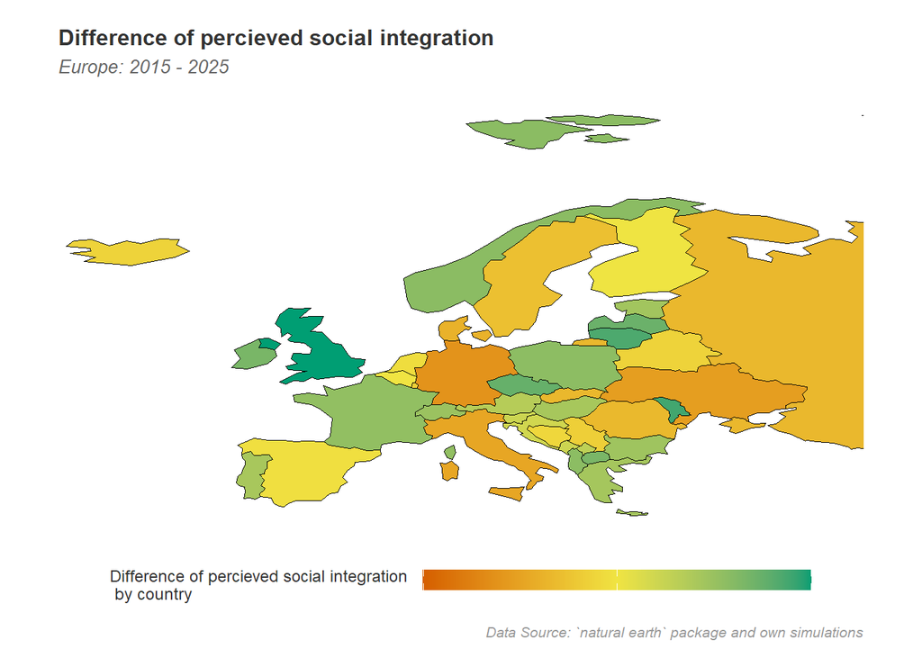

```r
#creating the good plot
good_plot <- ggplot(data = data_prepared) + #basic plot call
  geom_sf(aes(fill = -1 * loneliness_change), #inverting the `loneliness` values
          color = "black") + #creating the map of Europe
  labs(title = "Difference of percieved social integration", #adding a title
       subtitle = "Europe: 2015 - 2025", #adding a subtitle
       caption = "Data Source: `natural earth` package and own simulations") + #adding a caption
  scale_fill_gradient2(low = "#D55E00",
                       mid = "#F0E442",
                       high = "#009E73",
                       midpoint = 0,
                       limits = c(-10, 10),
                       breaks = c(-10, 0, 10),
                       labels = c("", "", ""),
                       name = "Difference of percieved social integration \n by country") + #adding an logical and intuitive legend
  coord_sf(xlim = c(-25, 45),
           ylim = c(30, 85),
           expand = FALSE) + #limiting the plot to continental Europe
  theme_void() + #minimizing the design
  theme(
    aspect.ratio = 0.6, #widening the card
    plot.margin = margin(10, 0, 10, 0), #keeping edge areas clear
    legend.position = "bottom",  #positioning the legend at the bottom
    legend.key.width = unit(1.5, "cm"),  #improving legends compactness
    legend.key.height = unit(0.4, "cm"),  #improving legends compactness
    legend.title = element_text(size = 9,
                                color = "#333333",
                                family = "helvetica",
                                vjust = 1),  #formatting legends title
    plot.title = element_text(size = 12,
                              face = "bold",
                              color = "#333333",
                              family = "Arial"), #formatting the plot' title
    plot.subtitle = element_text(size = 10,
                                 face = "italic",
                                 color = "#666666",
                                 family = "Arial"), #formatting the plot' subtitle
    plot.caption = element_text(size = 8,
                                face = "italic",
                                color = "#999999",
                                family = "Times New Roman") #formatting the plot' caption
  ) #additional design changes

#print out
good_plot
```

First and foremost, a good plot is one that fits the data and transports intuitively the most important message. In this case, geographical data (`countries_tidied`) was utilized. If geographical data is available, it is usually advisable to transfer these properties of the data to the graphic. Typically this is done by drawing the data on a map. However, there might be a reason not to. The accuracy of the data might be of high importance and will decrease if a map is applied. Though the other data fraction, the target data about perceived `loneliness` (or vice versa about perceived social integration) by European country in 2015 and 2025 respectively, was quite volatile (standard deviations of up to half the total scale). Drawing a precise picture of specific developments in a country would not have been of much value for any recipient. This lead to the final decision to opt for a map plot, which would give the viewer the fastest and most intuitive impression of broad trends across Europe.

Though choosing a map plot as plot type was the most basic decision, it was not the last one. Secondly, the data properties had to be transferred appropriately to the exact properties of the map and the rest of the plot, keeping the message accurate and easy to understand. The survey data measured `loneliness` so that a mathematically positive value of difference between the time points of 2015 and 2025 would mean an increase of perceived loneliness in a country between 2015 and 2025. An aspect content wise not considered as positive. To avoid this confusion between the mathematical interpretation and the content interpretation, within the call of `geom_sf()` the scale was inverted. The text within the plot, inserted by the `labs`-function, was adapted to this inversion and thus supported the interpretation of the scale to *social integration* . The inserted subtitle and caption specified the area of the plot and the data source, thus making the plot more accurate and transparent. Both can be considered as aspects following good scientific practice. To support the interpretation of the map the call `scale_fill_gradient2()` rearranged the color filling of the countries. The colors were selected taking into account (1) the intuitive interpretation of the social integration scale, meaning a mathematically and content wise negative value was colored increasingly red, a mathematically and content wise positive value was colored increasingly green, neutral values or those close to zero were colored yellow, thus overall creating a scale that corresponded to globally recognized color interpretations and the colors were selected taking into account (2) that people with a red/green deficiency would be able to perceive them without problems. This color scheme was made even easier accessible for the viewer by adding a legend with a logical and intuitive description underneath the map. Cause the purpose of the plot was to display broad and general trends rather than specific data points for a country, the exact scale of the underlying survey was of low value and thus the further description of the color legend was erased. Furthermore, to keep focus on continental Europe and support the viewer in observing the main message, `coord_sf()` blended out remote countries far west but under European political leadership (such as Greenland) or country parts reaching out far to the east (e.g. the case for Russia). All these aspects aim at and support the desired principles of simplicity and clarity in a plot.

As a final step, following these content adjustments, the overall plot had to be adapted and improved visually. The basis for this was to hide non-essential aspects of the plot using `theme_void()`. Final adjustments were made within the `theme()` call, specifying the width-height ratio of the map, border margins, the position and size of the color legend and font characteristics of title, subtitle, legend description and caption. All of these changes were made to improve the overall visibility and further clearness of the plot and support the viewer to focus on the most important aspects.

Taken together the conception, the transfer of data properties and the visual adjustments, this plot communicates its message intuitively, direct, accurate, clear, simple and easily visible and can therefore be seen as a good plot following good and established scientific practice.

## Bad plot

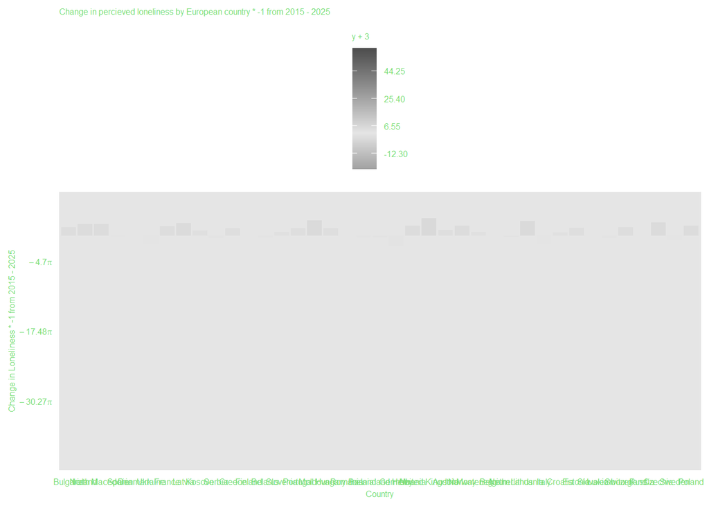

```r
#creating the bad plot
bad_plot <- ggplot(data = data_prepared) + #basic plot call
  geom_bar(stat = "identity", #setting metric value as relevant for bar height
           aes(x = factor(name,
                          levels = sample(unique(name))), #randomizing the order of countries
               y = (-1*loneliness_change) / pi, #inverting and recalculating the `loneliness` values
               fill = (-1*loneliness_change / pi) + 3)) + #filling the bars by inverted and recalculated `loneliness` value
  scale_fill_gradient2(low = "gray30",
                       mid = "gray90",
                       high = "gray30",
                       midpoint = sqrt(pi),
                       limits = c(-23, 60),
                       breaks = seq(-12.3, 45, round(6*pi,2)),
                       name = "y + 3") + #setting a distorting color range
  scale_y_continuous(limits = c(-40.73, 4*sqrt(2)),
                     breaks = seq(-30.27, 13.04, 4.07*pi),
                     labels = function(x) parse(text = paste0(round(x, 2)," *pi"))) + #setting distorting y-labels
#  geom_hline(yintercept = 0,
#             color = "black",
#             linetype = "solid") + #emphasizing the x-axis
#  coord_flip() + #switching x-axis and y-axis
  labs(title = "Change in percieved loneliness by European country * -1 from 2015 - 2025",
       x = "Country",
       y = "Change in Loneliness * -1 from 2015 - 2025") + #adding a plot title and axis titles
#  theme_void() + #minimizing the design
  theme(
  panel.grid = element_blank(), #removing grid lines
  panel.background = element_rect(fill = "grey90",
                                  colour = NA), #editing background color
  axis.ticks = element_blank(), #removing axis ticks
  legend.position = "top", #rearranging legend
  legend.direction = "vertical", #align legend
  plot.title = element_text(size = 6,
                            color = "#77DD77"), #editing size and color of...
  axis.title.x = element_text(size = 6,
                              color = "#77DD77"), #editing size and color of...
  axis.title.y = element_text(size = 6,
                              color = "#77DD77"), #editing size and color of...
  legend.title = element_text(size = 6,
                              color = "#77DD77"), #editing size and color of...
  legend.text = element_text(size = 6,
                             color = "#77DD77"), #editing size and color of...
  axis.text.x = element_text(size = 6,
                             color = "#77DD77"),  #editing size and color of...
  axis.text.y = element_text(size = 6,
                             color = "#77DD77")  #editing size and color of...
  )

#print out
bad_plot
```

In contrast to the good plot, a bad plot does not consider the data type on the concept level, a bad plot does not consider the properties of the data on the transfer level and a bad plot does not consider the viewer’s perspective of the final plot on the visual adjustment level, but ignores all of this - or even further - counteracts these fundamental considerations.

Applying a `geom_bar()` plot on geographical data is not a poor concept choice in principle. Though opting for a bar plot loses the *obvious* geographical dimension (e.g. it would be harder to locate trends in parts of Europe) and makes it harder for the viewer to draw conclusions. Further, for the present case, the goal of the plot was not to lose the viewer in details but give a brief but fast overview of the trend in the development. In summary, taking such a type of plot in a case such as the one provided here, was - although not the final destiny for a bad plot - of no help to make the plot directly and intuitively readable.

Further, the specific adjustments on the present `geom_bar()` do not transfer the data characteristics intuitively. Indeed, the opposite is the case. Already in the basic creation call of the plot, the order of the countries `name` was shuffled, resulting in a loss of information. Like in the example of the good plot above, the values of the `loneliness` scale were inverted. Generally this would have support the readability of the plot (as was discussed in more detail above), though dividing the data points with a value without any reason for it does not support a fast interpretation of the plot. Dividing the data points of perceived `loneliness` not just by any value, but by an oblique value such as *π* even increases this problem. To `fill` the bars with a color in dependence of the newly recalculated `loneliness` data points would have been redundant, but with suitable colors and a fitting color legend next to the graph, this could have indeed supported the interpretation for the viewer to some degree. Unfortunately, all of these possibilities were not realized, but - once more - instead they were implemented in a way which leads to even less simplicity and readability. The filling of the bars, again, used the recalculated values of the `loneliness` scale. Though the `scale_fill_gradient2()` call ensures that the legend description makes this calculation transparent, the viewer now has to conduct unnecessary calculations before the color of a specific bar plot can be interpreted. In combination with the choice of odd `breaks` and odd the `sequence` of the color legend, this problem gets worse. Not yet mentioned yet is the color selection within the `scale_fill_gradient2()` call, which leads to the bars hardly being distinguishable from the gray background and even getting so close to the background color at small values that it is unclear whether a data value was only very small or not present at all for a particular country. In sum, the legend becomes almost illegible. Inspired by this, the y-axis - which is supposed to reflect the unnecessarily complex transformed values briefly discussed above - indeed explicitly indicates that this transformation has taken place and must be recalculated by the viewer, but is so distorted by the arguments `limits`, `breaks` and `labels` that its readability is close to non existent. Even more, the argument `breaks` leads to a distortion of the y-axis which suggests that the data range is asymmetrical. Considering the data and the simulation of the data this is not the case. Besides the readability, also the intuitive approach to and clearness of the plot has suffered. Even more, applying `geom_hline()` would have helped to support the view of the viewer but was not applied here. Using the `coord-flip()` function to swap the x- and y-axes and thus eliminate the problem of overlapping country names on the current x-axis was also not applied. Both these aspects keep the plot readability low. The `labs()` (title and y-axis label) of the plot do state precisely the transformation of the data points on the y-axis and therefore are transparent and clear for the viewer. On the other hand, unlike in the good plot this was not done by changing the interpretation of the scale to *social integration* as well, reducing simplicity and clearness further. Taking all of this together, the plot still provides accurate data points, though the way of data transformation into the plot decreased the clearness, simplicity and mostly the readability.

Finally, the appearance of the entire plot has to be considered. Unlike in the example of the good plot, here it was avoided to apply the `theme_void()` to get rid of unnecessary plot aesthetics. This would have improved the simplicity and readability of the plot to some degree. Nevertheless, within the `theme()` call, the supporting grid lines and axis ticks, which would have provided support for the viewer to read data points, have been removed. As already briefly mentioned above, the background color was adopted in a way, that makes it close to impossible to distinguish if a country has a marginal data value or no data point at all. The readability is close to non existent for some data points cause of that reason. The color legend was unnecessarily and unusually pushed over the plot and was also not appropriately vertically aligned. Though this has no direct impact on the plots readability, it draws attention away from the key parts of the plot to the less interesting ones. Lastly, the plot title, axis titles and labels and legend title and legend were all formatted to a low size and color, decreasing the readability of the plot generally and even further for viewers with a red/green deficiency. In sum, all of these visual changes lead to no improved simplicity but a decreased readability of the plot.

Taken together the conception, the transfer of data properties and the visual adjustments, this plot - though an accurate representation of the data - communicates its message not intuitively, unclear, unnecessary complex and difficult to read and can therefore not be seen as a good plot following good and established scientific practice.